# COVID-19新冠肺炎疫情报告

## 一、背景介绍：

2020年伊始，新冠肺炎疫情突如其来，无疑成为我国乃至全球范围内的典型黑天鹅事件，打乱了原有社会的生活节奏和经济秩序。随着疫情在世界范围内的 蔓延，全球经济短期增长的不确定性增强，对全球产业链、商业模式及展业模式等均形成了一定的影响。

[figure not shown]

自2019年12月以来，新型冠状病毒疫情持续蔓延，整体形势复杂且严峻。据国家卫健委统计，截至2020年3月27日24时，累计治愈出院病例75123例，累计 死亡病例3301例。此次新冠肺炎病情蔓延快、规模大，从确诊病例的数量来看，非典疫情时期确诊病例为5327例，此次肺炎疫情病例数已超出非典时期病例 总数的数十倍以上，且当前全国所有省级行政区均已出现确诊病例，并均已启动重大突发公共卫生事件一级响应。本次肺炎影响的不仅是普通百姓，更有多国 政界领导不幸感染，2月27日伊朗副总统玛苏梅·埃卜特卡尔确诊感染新冠肺炎，3月27日英国首相约翰逊被曝出新冠病毒检测呈阳性，更有西班牙皇室成员因 新冠肺炎逝世。

从国内疫情角度看，我国3月12日达到每日新增数量最低点，总确诊新增病例11人，随后全国整体疫情得到了初步控制，后期新增人数中境外输入人数占大部分 比例，截止3月27日，我国每日新增确诊人数达到135人，其中新增境外输入人数54人，占比40%。

从国外疫情角度看，情况则呈失控状态，根据3月27日最新数据，除中国外有8国确诊病例破万，美国超10万例居首位。截止3月27日，累计确诊人数暴增至 517539例，而累计治愈人数仅为59178例，占11%，累计死亡人数高达24103例，占4.66%，情况不容乐观。纵观疫情发展时间线，2月26日是国内外的重要 拐点，该日中国新增确诊人数为440人，国外新增确诊人数为459人，国外首次超过中国，自该日之后国外每日新增确诊人数急剧飙升，3月15日国外每日新增 确诊人数首次破万，达到10955人。以3月27日最新数据来看，国外每日新增46367人，其中美国、意大利、西班牙每日新增人数分别为19253人、5959人、 7933人，为全球累计确诊人数最多的三个境外国家。

## 二、国内情况：

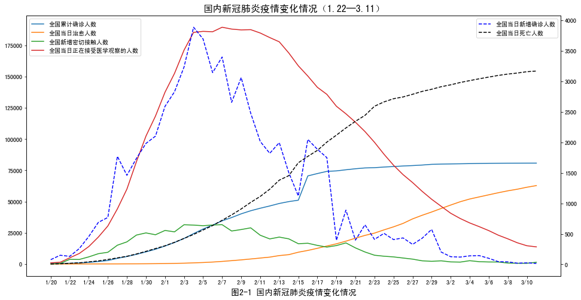

```python
import matplotlib.pyplot as plt
import numpy as np
import pandas as pd
from datetime import datetime

# from matplotlib.font_manager import _rebuild
# _rebuild()
plt.rcParams['font.sans-serif']=['SimHei']

fig = plt.figure(figsize = (16,8))
ax = fig.add_subplot(1,1,1)

ax.set_title("国内新冠肺炎疫情变化情况（1.22—3.11）",fontsize=16)
ax.set_xlabel('图2-1 国内新冠肺炎疫情变化情况',fontsize=14)

data = pd.read_csv('ncov_311.csv', index_col=0, parse_dates=True)


ax.plot(data['confirmed_count'],label = '全国累计确诊人数')
ax.plot(data['cure_count'],label = '全国当日治愈人数')
ax.plot(data['new_contact'],label = '全国新增密切接触人数')
ax.plot(data['observe_count'],label = '全国当日正在接受医学观察的人数')


ax2 = ax.twinx()
ax2.plot(data['new_confirmed'],'b--',label='全国当日新增确诊人数')
ax2.plot(data['dead_count'],'k--',label='全国当日死亡人数')


ax.legend(loc = 'upper left')
ax2.legend(loc = 'upper right')

x_label = data.index
xticks = plt.xticks(x_label[::2],rotation=45)
```

图2-1展示了1月22日到3月11日国内新冠肺炎疫情变化情况，包含6个量化指标：

```python
dict1 = {'名称':["全国当日新增确诊人数","全国累计确诊人数","全国当日死亡人数","全国当日治愈人数",
               "全国当日正在接受医学观察的人数","全国新增密切接触人数"],
         '指标':list(data.columns[:6])}

index1 = pd.DataFrame(dict1)
index1.name = '国内新冠肺炎疫情变化情况指标说明'
index1
```

|  | 名称 | 指标 |
| --- | --- | --- |
| 0 | 全国当日新增确诊人数 | new_confirmed |
| 1 | 全国累计确诊人数 | confirmed_count |
| 2 | 全国当日死亡人数 | dead_count |
| 3 | 全国当日治愈人数 | cure_count |
| 4 | 全国当日正在接受医学观察的人数 | new_contact |
| 5 | 全国新增密切接触人数 | observe_count |

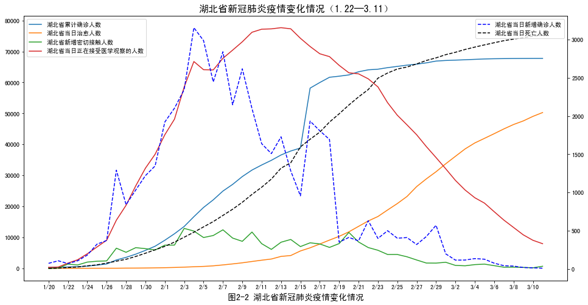

```python
fig = plt.figure(figsize = (16,8))
ax = fig.add_subplot(1,1,1)

ax.set_title("湖北省新冠肺炎疫情变化情况（1.22—3.11）",fontsize=16)
ax.set_xlabel('图2-2 湖北省新冠肺炎疫情变化情况',fontsize=14)

data = pd.read_csv('ncov_311.csv', index_col=0, parse_dates=True)


ax.plot(data['Hubei_confirmed_count'],label = '湖北省累计确诊人数')
ax.plot(data['Hubei_cure_count'],label = '湖北省当日治愈人数')
ax.plot(data['Hubei_new_contact'],label = '湖北省新增密切接触人数')
ax.plot(data['Hubei_observe_count'],label = '湖北省当日正在接受医学观察的人数')


ax2 = ax.twinx()
ax2.plot(data['Hubei_new_confirmed'],'b--',label='湖北省当日新增确诊人数')
ax2.plot(data['Hubei_dead_count'],'k--',label='湖北省当日死亡人数')


ax.legend(loc = 'upper left')
ax2.legend(loc = 'upper right')

x_label = data.index
xticks = plt.xticks(x_label[::2],rotation = 45)
```

图2-2展示了本次疫情中心湖北省新冠肺炎疫情变化情况，同样包含6个量化指标：

```python
dict2 = {'名称':["湖北省当日新增确诊人数","湖北省累计确诊人数","湖北省当日死亡人数","湖北省当日治愈人数","湖北省当日正在接受医学观察的人数","湖北省新增密切接触人数"],
         '指标':list(data.columns[6:13])}

index2 = pd.DataFrame(dict2)
index2.name = '国内新冠肺炎疫情变化情况指标说明'
index2
```

|  | 名称 | 指标 |
| --- | --- | --- |
| 0 | 湖北省当日新增确诊人数 | Hubei_new_confirmed |
| 1 | 湖北省累计确诊人数 | Hubei_confirmed_count |
| 2 | 湖北省当日死亡人数 | Hubei_dead_count |
| 3 | 湖北省当日治愈人数 | Hubei_cure_count |
| 4 | 湖北省当日正在接受医学观察的人数 | Hubei_new_contact |
| 5 | 湖北省新增密切接触人数 | Hubei_observe_count |

可以清晰地观察得到，湖北省的疫情变化基本与全国同步，可以说湖北省的情况占了全国情况的80%以上， 在本次疫情中，湖北省每日新增病例最高达到3156人，峰值时有77685人同时接受医学观察，截止3月11日， 累计确诊人数为67781人，累计死亡人数为3056人，死亡率为4.51%，累计治愈人数为50298人，治愈率为 74.21%，疫情基本得到控制。

## 三、各省情况：

```python
'''数据导入与处理'''
city_data = pd.read_excel('CityTS_219.xlsx')
city_data.fillna(0,inplace=True)

mydate = city_data.iloc[:,1][22]    # 截止日期：2020-2-19
mycity = city_data.iloc[:, 0].drop_duplicates()     # 8+5+8省份、城市列表
mycity1, mycity2, mycity3 = mycity[:8],mycity[8:13],mycity[13:] # 8省、湖北5市、8个一线重点城市
mycity1_ = mycity1.drop(46)
mycity1.name = None
```

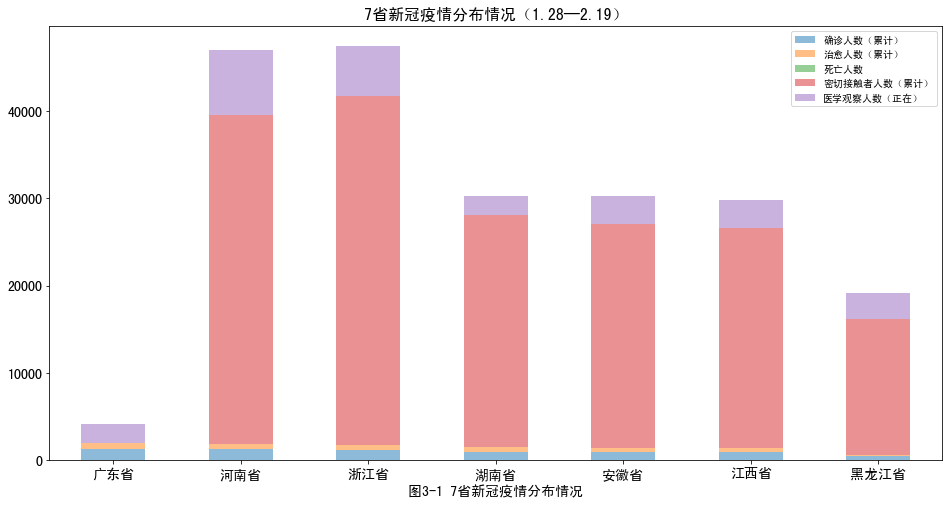

```python
'''堆积柱状图：7省新冠疫情分布情况（1.28-2.19）'''
city1 = city_data[city_data.iloc[:,1] == mydate].iloc[:8,:] # 8省份分布情况
city1 = city1.drop(68)

city2 = pd.DataFrame(city1.iloc[:,2:7])
city2.index = mycity1_
city2.index.name = None
city2.sort_values(['确诊人数（累计）'],ascending=False,inplace=True)
city2.plot.bar(stacked=True, alpha = 0.5,figsize = (16,8),fontsize=14)
plt.xticks(rotation = 0)
plt.title("7省新冠疫情分布情况（1.28—2.19）",fontsize=16)
plt.xlabel('图3-1 7省新冠疫情分布情况',fontsize=14)
plt.show()
```

图3-1展示了在1月28日到2月19日之间，七个省份（广东、河南、浙江、湖南、安徽、江西）新冠疫情分布情况，截止2月19日，广东省累计确诊人数最多， 达到了1332人，最低的是黑龙江省，为476人。但医学观察人数却呈不与确诊人数成正比，最多的是河南省，为7498人，最低的为广东省，为2172人； 从治愈人数来看，广东省为619人，名列第一，这表明广东省的医疗确诊效率较高，有效地将病患及时确诊治疗，降低医疗资源负担。死亡人数最高的两个 省为河南省和黑龙江省，分别为19人、12人，死亡率为1.50%、2.52%，表明黑龙江省虽然确诊人数低，但死亡率较高，其医疗效率较为低下。

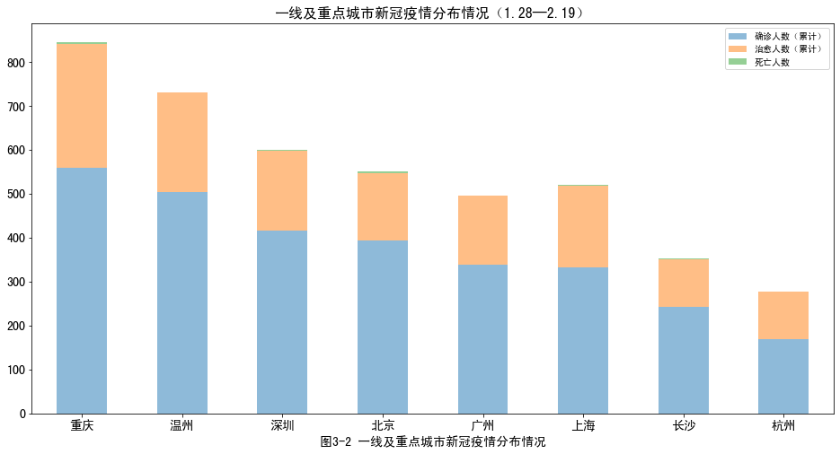

```python
'''堆积柱状图：一线及重点城市新冠疫情分布情况（1.28—2.19）'''
city1 = city_data[city_data.iloc[:,1] == mydate].iloc[13:,:]

city2 = pd.DataFrame(city1.iloc[:,2:5])
city2.index = mycity3
city2.index.name = None
city2.sort_values(['确诊人数（累计）'],ascending=False,inplace=True)
city2.plot.bar(stacked = True, alpha = 0.5,figsize = (16,8),fontsize=14)
plt.xticks(rotation = 0)
plt.title("一线及重点城市新冠疫情分布情况（1.28—2.19）",fontsize=16)
plt.xlabel('图3-2 一线及重点城市新冠疫情分布情况',fontsize=14)
plt.show()
```

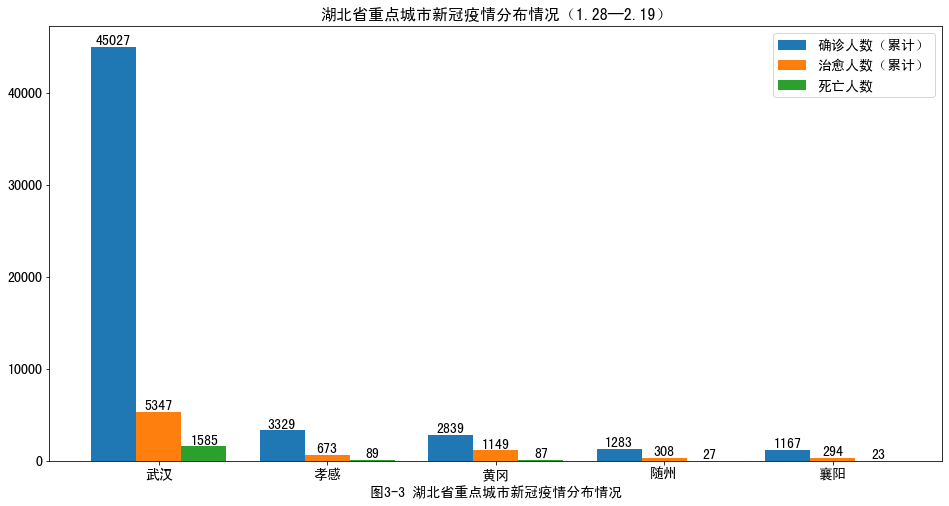

```python
'''柱状图：湖北省重点城市新冠疫情分布情况（1.28—2.19）'''
city1 = city_data[city_data.iloc[:,1] == mydate].iloc[8:13,:]

city2 = pd.DataFrame(city1.iloc[:,2:5])
city2.index = mycity2
city2.index.name = None
city2.sort_values(['确诊人数（累计）'],ascending=False,inplace=True)

fig = plt.figure()
c = city2.plot(kind='bar', y=['确诊人数（累计）','治愈人数（累计）','死亡人数'],
               figsize=(16,8),width=0.8,fontsize=14)

plt.legend(fontsize=14) # 设置图例
plt.title("湖北省重点城市新冠疫情分布情况（1.28—2.19）",fontsize=16)
# 数据标签列表
x = np.arange(len(city2.index))
yv = np.array(list(city2['确诊人数（累计）']))
ys = np.array(list(city2['治愈人数（累计）']))
yn = np.array(list(city2['死亡人数']))
for a,b in zip(x,yv): #控制标签位置
    plt.text(a-0.27,b+0.1,'%d'%b,ha = 'center',va = 'bottom',fontsize=14)
for a,b in zip(x,ys):
    plt.text(a,b+0.1,'%d'%b,ha = 'center',va = 'bottom',fontsize=14)
for a,b in zip(x,yn):
    plt.text(a+0.27,b+0.1,'%d'%b,ha = 'center',va = 'bottom',fontsize=14)
plt.xticks(rotation = 0)
plt.xlabel('图3-3 湖北省重点城市新冠疫情分布情况',fontsize=14)
plt.show()
```

图3-3展示了疫情最严重的湖北省内五个城市的疫情分布情况，其中武汉位居首位，截止2月19日，累计确诊人数高达45027人，累计治愈人数为5347人， 累计死亡人数为1585人，齐次为孝感、黄冈、随州、襄阳。全省平均治愈率为14%，武汉治愈率最低，为12%，黄冈治愈率最高，为40%，除武汉外各市 治愈率均高于平均水平。全省平均死亡率为3%，各市死亡率基本相等。

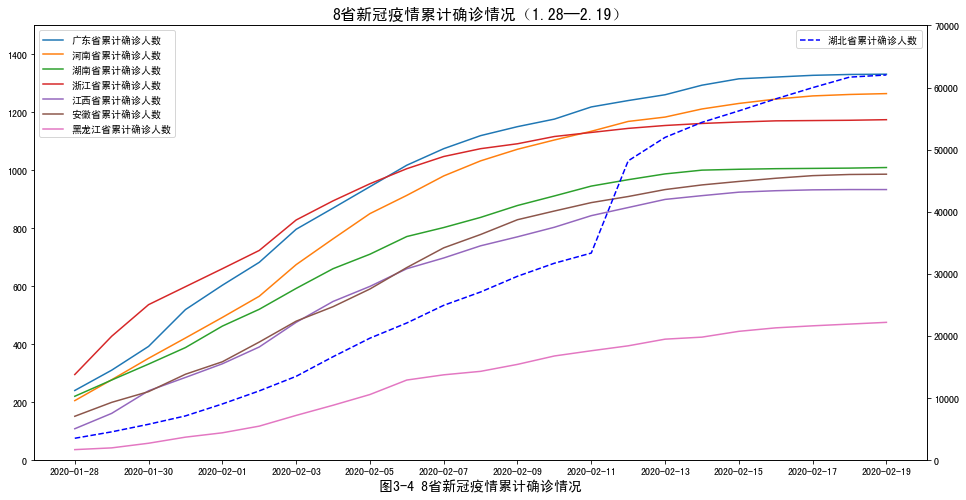

```python
fig = plt.figure(figsize = (16,8))
ax = fig.add_subplot(1,1,1)

ax.set_title("8省新冠疫情累计确诊情况（1.28—2.19）",fontsize=16)
ax.set_xlabel('图3-4 8省新冠疫情累计确诊情况',fontsize=14)

myprovince = list(mycity1)

province_data = []
for i in range(8):
    province = np.array(city_data[city_data.iloc[:,0] == myprovince[i]].iloc[:,2],dtype = np.int64)
    province_data.append(province)
province_data = np.array(province_data)
province_data

my_date = city_data.iloc[:,1].drop_duplicates()
my_date = [i.strftime('%Y-%m-%d') for i in my_date]

province_data_ = pd.DataFrame(province_data,columns = my_date,index = mycity1)
province_data_.loc['广东省']

ax.plot(province_data_.loc['广东省'],label = '广东省累计确诊人数')
ax.plot(province_data_.loc['河南省'],label = '河南省累计确诊人数')
ax.plot(province_data_.loc['湖南省'],label = '湖南省累计确诊人数')
ax.plot(province_data_.loc['浙江省'],label = '浙江省累计确诊人数')
ax.plot(province_data_.loc['江西省'],label = '江西省累计确诊人数')
ax.plot(province_data_.loc['安徽省'],label = '安徽省累计确诊人数')
ax.plot(province_data_.loc['黑龙江省'],label = '黑龙江省累计确诊人数')
plt.ylim([0,1500])

ax2 = ax.twinx()
ax2.plot(province_data_.loc['湖北省'],'b--',label='湖北省累计确诊人数')
plt.ylim([0,70000])

ax.legend(loc = 'upper left')
ax2.legend(loc = 'upper right')

x_label = province_data_.columns
xticks = plt.xticks(x_label[::2],rotation=45)
```

图3-4展示了重点八个省份自1月28日到2月19日的每日疫情变化情况，以累计确诊人数代表整体疫情发展情况，可以看到湖北省毋庸置疑为 榜首，累计确诊人数为62031人，平均每日新增2542人，其次为广东省，最终累计确诊人数为1332人，平均每日新增47人，情况最好的 是黑龙江省，最终累计确诊人数为476人，平均每日新增19人。其中湖南省疫情防控最为出色，虽然其累计确诊人数为1010人排名第四， 但其日均新增人数控制在34人，是除黑龙江省以外，日均增速最低的省份。

## 四、关于治愈率的探索

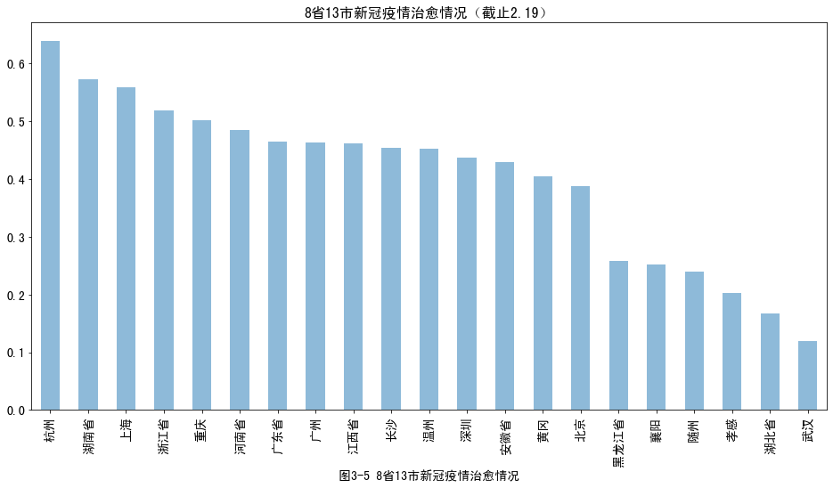

```python
cure = city_data[city_data.iloc[:,1] == mydate].iloc[:,[0,2,3]]
cure['治愈率'] = cure['治愈人数（累计）']/cure['确诊人数（累计）']
cure.sort_values(['治愈率'],ascending=False,inplace=True)
cure.index = cure.iloc[:,0]
cure2 = cure.iloc[:,3]

cure2.plot.bar(alpha = 0.5,figsize = (16,8),fontsize=14)
plt.title("8省13市新冠疫情治愈情况（截止2.19）",fontsize=16)
plt.xlabel('图3-5 8省13市新冠疫情治愈情况',fontsize=14)
plt.show()
```

图3-5展示了8省13市整体治愈率情况，这里治愈率的计算用了简单的除法公式，即累计治愈人数/累计确诊人数，可以看到在市级层面，杭州市的 治愈率名列第一，超过60%，最低的是武汉，不足20%，其中疫情中心湖北省5个重点城市中有4个城市的治愈率都低于30%，可见疫情中心地的情况 不容乐观，唯有黄冈市在疫情中表现出色，治愈率是5个城市中最高的，达到了40%。在省级层面来看，最邻近湖北省的湖南省却是治愈率最高的省份， 接近60%，可见防疫工作做得相当出色，除了湖北省外，治愈率最低的是黑龙江省，不足30%，可见东北偏远地区的防疫工作做得不太到位，亟需改进。 8省13市的整体平均治愈率为40.33%，还有提升空间。